# Data Visualisation

Data visualisation in Pandas Notebook

```python
import pandas as pd
import numpy as np
import matplotlib.pyplot as plt
```

```python
daily_prices = pd.read_parquet('./samples_rw/visualisation/sp500_daily_prices.parquet', engine='fastparquet')
daily_prices.head(3)
```

|  | date | close | symbol |
| --- | --- | --- | --- |
| 2544 | 2010-01-04 | 31.30 | A |
| 2545 | 2010-01-05 | 30.96 | A |
| 2546 | 2010-01-06 | 30.85 | A |

```python
daily_prices.info()
```

```
<class 'pandas.core.frame.DataFrame'>
Index: 1610669 entries, 2544 to 24292498
Data columns (total 3 columns):
 #   Column  Non-Null Count    Dtype
---  ------  --------------    -----
 0   date    1610669 non-null  datetime64[us]
 1   close   1610669 non-null  float64
 2   symbol  1610669 non-null  object
dtypes: datetime64[us](1), float64(1), object(1)
memory usage: 49.2+ MB
```

```python
apple = daily_prices.loc[daily_prices.symbol == 'AAPL']
apple.head(3)
```

|  | date | close | symbol |
| --- | --- | --- | --- |
| 79646 | 2010-01-04 | 7.6432 | AAPL |
| 79647 | 2010-01-05 | 7.6564 | AAPL |
| 79648 | 2010-01-06 | 7.5346 | AAPL |

```python
stocks = ( daily_prices
          .loc[daily_prices.symbol.isin(['AAPL', 'IBM', 'BA', 'NVDA'])]
          .pivot(index='date', columns='symbol', values='close')
          )
```

```python
stocks
```

| symbol date | AAPL | BA | IBM | NVDA |
| --- | --- | --- | --- | --- |
| 2010-01-04 | 7.6432 | 56.18 | 132.45 | 4.6225 |
| 2010-01-05 | 7.6564 | 58.02 | 130.85 | 4.6900 |
| 2010-01-06 | 7.5346 | 59.78 | 130.00 | 4.7200 |
| 2010-01-07 | 7.5207 | 62.20 | 129.55 | 4.6275 |
| 2010-01-08 | 7.5707 | 61.60 | 130.85 | 4.6375 |
| ... | ... | ... | ... | ... |
| 2023-08-01 | 195.6050 | 238.01 | 143.33 | 465.0700 |
| 2023-08-02 | 192.5800 | 231.38 | 144.17 | 442.6900 |
| 2023-08-03 | 191.1700 | 231.36 | 144.45 | 445.1500 |
| 2023-08-04 | 181.9900 | 231.36 | 144.24 | 446.8000 |
| 2023-08-07 | 179.3200 | 236.56 | 145.91 | 453.5800 |

3421 rows × 4 columns

# Line Plots

Create a simple line plot

```python
ts = pd.Series(np.random.randn(365), index=pd.date_range('1/1/2023', periods=365, freq='D'))
ts
```

```
2023-01-01   -1.222679
2023-01-02    0.062610
2023-01-03    1.437740
2023-01-04   -1.419430
2023-01-05   -1.202538
                ...
2023-12-27   -1.424048
2023-12-28   -0.936445
2023-12-29    0.217033
2023-12-30   -0.542274
2023-12-31    1.093770
Freq: D, Length: 365, dtype: float64
```

```python
ts = ts.cumsum()
```

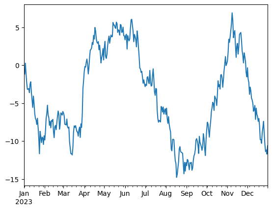

```python
ts.plot()
```

```python
apple
```

|  | date | close | symbol |
| --- | --- | --- | --- |
| 79646 | 2010-01-04 | 7.6432 | AAPL |
| 79647 | 2010-01-05 | 7.6564 | AAPL |
| 79648 | 2010-01-06 | 7.5346 | AAPL |
| 79649 | 2010-01-07 | 7.5207 | AAPL |
| 79650 | 2010-01-08 | 7.5707 | AAPL |
| ... | ... | ... | ... |
| 83065 | 2023-08-01 | 195.6050 | AAPL |
| 83066 | 2023-08-02 | 192.5800 | AAPL |
| 83067 | 2023-08-03 | 191.1700 | AAPL |
| 83068 | 2023-08-04 | 181.9900 | AAPL |
| 83069 | 2023-08-07 | 179.3200 | AAPL |

3421 rows × 3 columns

We need to set index and Y axis for APPL dataframe to be correctly plotted on the screen:

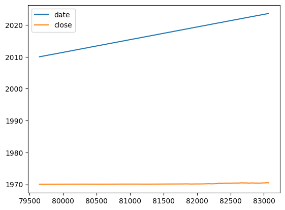

```python
apple.plot()
```

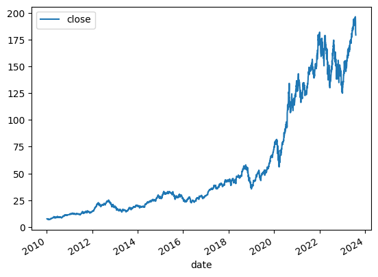

```python
apple.plot(x='date', y='close')
```

## Plot all columns data from the dataframe

Let's plot all of trends for the selected stock

```python
stocks
```

| symbol date | AAPL | BA | IBM | NVDA |
| --- | --- | --- | --- | --- |
| 2010-01-04 | 7.6432 | 56.18 | 132.45 | 4.6225 |
| 2010-01-05 | 7.6564 | 58.02 | 130.85 | 4.6900 |
| 2010-01-06 | 7.5346 | 59.78 | 130.00 | 4.7200 |
| 2010-01-07 | 7.5207 | 62.20 | 129.55 | 4.6275 |
| 2010-01-08 | 7.5707 | 61.60 | 130.85 | 4.6375 |
| ... | ... | ... | ... | ... |
| 2023-08-01 | 195.6050 | 238.01 | 143.33 | 465.0700 |
| 2023-08-02 | 192.5800 | 231.38 | 144.17 | 442.6900 |
| 2023-08-03 | 191.1700 | 231.36 | 144.45 | 445.1500 |
| 2023-08-04 | 181.9900 | 231.36 | 144.24 | 446.8000 |
| 2023-08-07 | 179.3200 | 236.56 | 145.91 | 453.5800 |

3421 rows × 4 columns

Here in the stocks, the date format is the index.

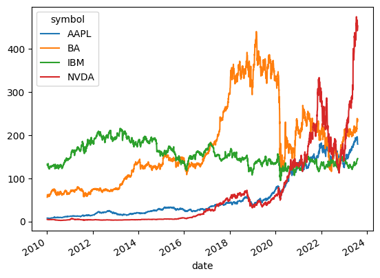

```python
stocks.plot()
```

## Add title

Add title to the plot

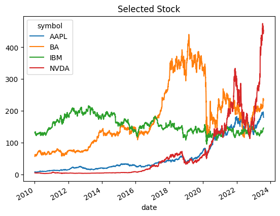

```python
stocks.plot(title='Selected Stock')
```

## Labeling Plot

Adding labels to the plot.

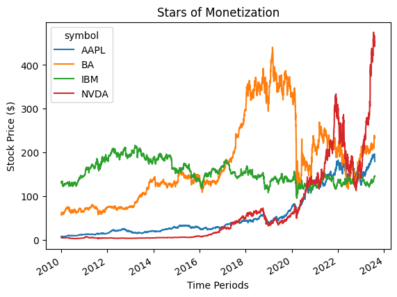

```python
stocks.plot(title='Stars of Monetization', xlabel='Time Periods', ylabel='Stock Price ($)')
```

## Legent setting

Modify / unable legend on the plot.

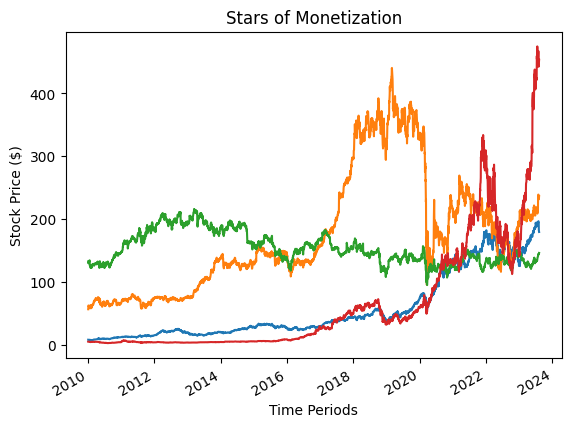

```python
stocks.plot(title='Stars of Monetization', xlabel='Time Periods', ylabel='Stock Price ($)', legend=False)
```

## Colours - customisation

Customise the colour on the plot.

cmpa parameter to set the plot theme on mathplotlib.

https://matplotlib.org/stable/users/explain/colors/colormaps.html

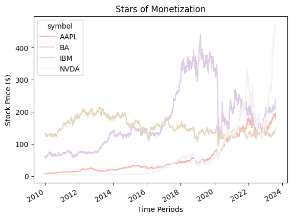

```python
stocks.plot(title='Stars of Monetization', xlabel='Time Periods', ylabel='Stock Price ($)', cmap='Pastel1')
```

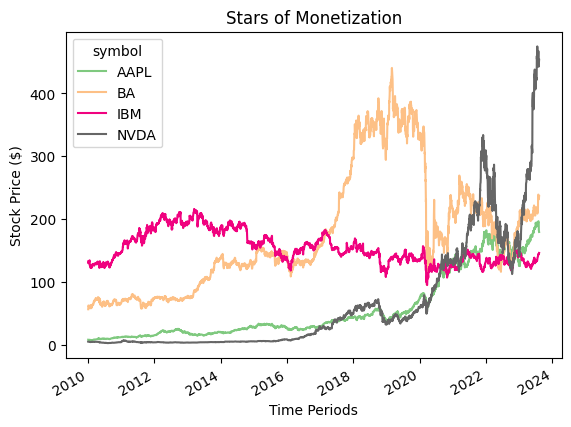

```python
stocks.plot(title='Stars of Monetization', xlabel='Time Periods', ylabel='Stock Price ($)', cmap='Accent')
```

## Add secondary Y axis

We always can add secondary axis of Y

As below it will be automatically be added to the plot, second syntax row is added ...

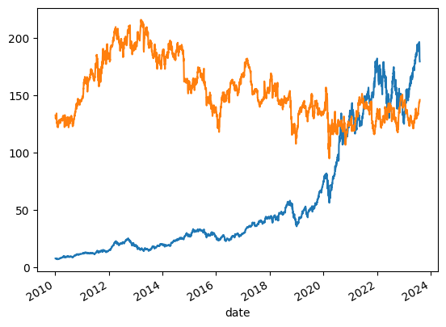

```python
stocks['AAPL'].plot()
stocks['IBM'].plot()
```

I would like separate axis for the IBM

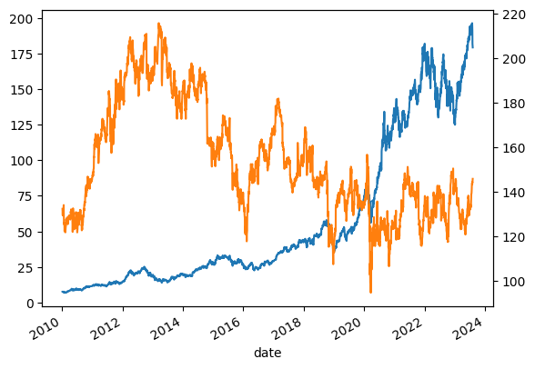

```python
stocks['AAPL'].plot()
stocks['IBM'].plot(secondary_y=True)
```

## Size of the graph

Control size of the graph

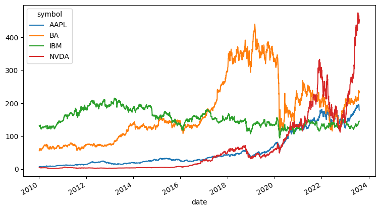

```python
stocks.plot(figsize=(9, 5))
```

# Subplots

In the example below, I want one single layout with 4 separated plots inside it.

```
array([[<Axes: xlabel='date'>, <Axes: xlabel='date'>,
        <Axes: xlabel='date'>, <Axes: xlabel='date'>]], dtype=object)
```

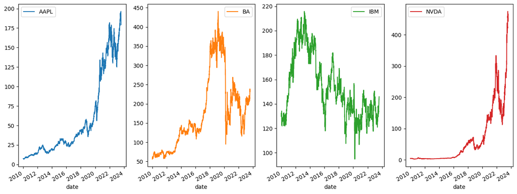

```python
stocks.plot(subplots=True, layout=(1, 4), figsize=(16,6))
```

## scaling the axes

But , the scale is different for each internal plit.

Let's make the Y axis in the same range:

```
array([[<Axes: xlabel='date'>, <Axes: xlabel='date'>,
        <Axes: xlabel='date'>, <Axes: xlabel='date'>]], dtype=object)
```

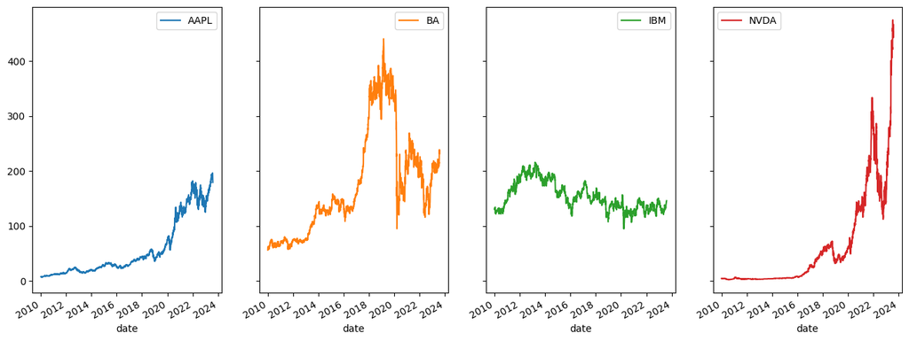

```python
stocks.plot(subplots=True, layout=(1, 4), figsize=(16,6), sharey=True)
```